# INN Hotels Project

## Context

A significant number of hotel bookings are called-off due to cancellations or no-shows. The typical reasons for cancellations include change of plans, scheduling conflicts, etc. This is often made easier by the option to do so free of charge or preferably at a low cost which is beneficial to hotel guests but it is a less desirable and possibly revenue-diminishing factor for hotels to deal with. Such losses are particularly high on last-minute cancellations.

The new technologies involving online booking channels have dramatically changed customers’ booking possibilities and behavior. This adds a further dimension to the challenge of how hotels handle cancellations, which are no longer limited to traditional booking and guest characteristics.

The cancellation of bookings impact a hotel on various fronts:

- Loss of resources (revenue) when the hotel cannot resell the room.
- Additional costs of distribution channels by increasing commissions or paying for publicity to help sell these rooms.
- Lowering prices last minute, so the hotel can resell a room, resulting in reducing the profit margin.
- Human resources to make arrangements for the guests.

## Objective

The increasing number of cancellations calls for a Machine Learning based solution that can help in predicting which booking is likely to be canceled. INN Hotels Group has a chain of hotels in Portugal, they are facing problems with the high number of booking cancellations and have reached out to your firm for data-driven solutions. You as a data scientist have to analyze the data provided to find which factors have a high influence on booking cancellations, build a predictive model that can predict which booking is going to be canceled in advance, and help in formulating profitable policies for cancellations and refunds.

## Data Description

The data contains the different attributes of customers' booking details. The detailed data dictionary is given below.

**Data Dictionary**

- Booking_ID: unique identifier of each booking
- no_of_adults: Number of adults
- no_of_children: Number of Children
- no_of_weekend_nights: Number of weekend nights (Saturday or Sunday) the guest stayed or booked to stay at the hotel
- no_of_week_nights: Number of week nights (Monday to Friday) the guest stayed or booked to stay at the hotel
- type_of_meal_plan: Type of meal plan booked by the customer:
  - Not Selected – No meal plan selected
  - Meal Plan 1 – Breakfast
  - Meal Plan 2 – Half board (breakfast and one other meal)
  - Meal Plan 3 – Full board (breakfast, lunch, and dinner)
- required_car_parking_space: Does the customer require a car parking space? (0 - No, 1- Yes)
- room_type_reserved: Type of room reserved by the customer. The values are ciphered (encoded) by INN Hotels.
- lead_time: Number of days between the date of booking and the arrival date
- arrival_year: Year of arrival date
- arrival_month: Month of arrival date
- arrival_date: Date of the month
- market_segment_type: Market segment designation.
- repeated_guest: Is the customer a repeated guest? (0 - No, 1- Yes)
- no_of_previous_cancellations: Number of previous bookings that were canceled by the customer prior to the current booking
- no_of_previous_bookings_not_canceled: Number of previous bookings not canceled by the customer prior to the current booking
- avg_price_per_room: Average price per day of the reservation; prices of the rooms are dynamic. (in euros)
- no_of_special_requests: Total number of special requests made by the customer (e.g. high floor, view from the room, etc)
- booking_status: Flag indicating if the booking was canceled or not.

## Importing necessary libraries and data

```python
# Library to suppress warnings or deprecation notes
import warnings

warnings.filterwarnings("ignore")

# Libraries to help with reading and manipulating data

import pandas as pd
import numpy as np

# Library to split data
from sklearn.model_selection import train_test_split

# libaries to help with data visualization
import matplotlib.pyplot as plt
import seaborn as sns

# Removes the limit for the number of displayed columns
pd.set_option("display.max_columns", None)
# Sets the limit for the number of displayed rows
pd.set_option("display.max_rows", 200)

import statsmodels.stats.api as sms
from statsmodels.stats.outliers_influence import variance_inflation_factor
import statsmodels.api as sm
from statsmodels.tools.tools import add_constant
from sklearn.linear_model import LogisticRegression

# Libraries to build decision tree classifier
from sklearn.tree import DecisionTreeClassifier
from sklearn import tree

# To tune different models
from sklearn.model_selection import GridSearchCV

# To perform statistical analysis
import scipy.stats as stats

# To get diferent metric scores
from sklearn.metrics import (
    f1_score,
    accuracy_score,
    recall_score,
    precision_score,
    confusion_matrix,
    roc_auc_score,
    plot_confusion_matrix,
    precision_recall_curve,
    roc_curve,
    make_scorer
)
```

## Data Overview

- Observations
- Sanity checks

```python
data = pd.read_csv('INNHotelsGroup.csv')
```

**Create a copy of the data to prevent accidental data manipulation.**

```python
hotel_data = data.copy()
```

**Look at the top 10 rows of the dataset**

```python
hotel_data.head(10)
```

|  | Booking_ID | no_of_adults | no_of_children | no_of_weekend_nights | no_of_week_nights | type_of_meal_plan | required_car_parking_space | room_type_reserved | lead_time | arrival_year | arrival_month | arrival_date | market_segment_type | repeated_guest | no_of_previous_cancellations | no_of_previous_bookings_not_canceled | avg_price_per_room | no_of_special_requests | booking_status |
| --- | --- | --- | --- | --- | --- | --- | --- | --- | --- | --- | --- | --- | --- | --- | --- | --- | --- | --- | --- |
| 0 | INN00001 | 2 | 0 | 1 | 2 | Meal Plan 1 | 0 | Room_Type 1 | 224 | 2017 | 10 | 2 | Offline | 0 | 0 | 0 | 65.00 | 0 | Not_Canceled |
| 1 | INN00002 | 2 | 0 | 2 | 3 | Not Selected | 0 | Room_Type 1 | 5 | 2018 | 11 | 6 | Online | 0 | 0 | 0 | 106.68 | 1 | Not_Canceled |
| 2 | INN00003 | 1 | 0 | 2 | 1 | Meal Plan 1 | 0 | Room_Type 1 | 1 | 2018 | 2 | 28 | Online | 0 | 0 | 0 | 60.00 | 0 | Canceled |
| 3 | INN00004 | 2 | 0 | 0 | 2 | Meal Plan 1 | 0 | Room_Type 1 | 211 | 2018 | 5 | 20 | Online | 0 | 0 | 0 | 100.00 | 0 | Canceled |
| 4 | INN00005 | 2 | 0 | 1 | 1 | Not Selected | 0 | Room_Type 1 | 48 | 2018 | 4 | 11 | Online | 0 | 0 | 0 | 94.50 | 0 | Canceled |
| 5 | INN00006 | 2 | 0 | 0 | 2 | Meal Plan 2 | 0 | Room_Type 1 | 346 | 2018 | 9 | 13 | Online | 0 | 0 | 0 | 115.00 | 1 | Canceled |
| 6 | INN00007 | 2 | 0 | 1 | 3 | Meal Plan 1 | 0 | Room_Type 1 | 34 | 2017 | 10 | 15 | Online | 0 | 0 | 0 | 107.55 | 1 | Not_Canceled |
| 7 | INN00008 | 2 | 0 | 1 | 3 | Meal Plan 1 | 0 | Room_Type 4 | 83 | 2018 | 12 | 26 | Online | 0 | 0 | 0 | 105.61 | 1 | Not_Canceled |
| 8 | INN00009 | 3 | 0 | 0 | 4 | Meal Plan 1 | 0 | Room_Type 1 | 121 | 2018 | 7 | 6 | Offline | 0 | 0 | 0 | 96.90 | 1 | Not_Canceled |
| 9 | INN00010 | 2 | 0 | 0 | 5 | Meal Plan 1 | 0 | Room_Type 4 | 44 | 2018 | 10 | 18 | Online | 0 | 0 | 0 | 133.44 | 3 | Not_Canceled |

**Data looks good. There are no NaN values in the above snippet.**

**Look at the bottom 10 rows of the dataset.**

```python
hotel_data.tail(10)
```

|  | Booking_ID | no_of_adults | no_of_children | no_of_weekend_nights | no_of_week_nights | type_of_meal_plan | required_car_parking_space | room_type_reserved | lead_time | arrival_year | arrival_month | arrival_date | market_segment_type | repeated_guest | no_of_previous_cancellations | no_of_previous_bookings_not_canceled | avg_price_per_room | no_of_special_requests | booking_status |
| --- | --- | --- | --- | --- | --- | --- | --- | --- | --- | --- | --- | --- | --- | --- | --- | --- | --- | --- | --- |
| 36265 | INN36266 | 2 | 0 | 1 | 3 | Meal Plan 1 | 0 | Room_Type 1 | 15 | 2018 | 5 | 30 | Online | 0 | 0 | 0 | 100.73 | 0 | Not_Canceled |
| 36266 | INN36267 | 2 | 0 | 2 | 2 | Meal Plan 1 | 0 | Room_Type 2 | 8 | 2018 | 3 | 4 | Online | 0 | 0 | 0 | 85.96 | 1 | Canceled |
| 36267 | INN36268 | 2 | 0 | 1 | 0 | Not Selected | 0 | Room_Type 1 | 49 | 2018 | 7 | 11 | Online | 0 | 0 | 0 | 93.15 | 0 | Canceled |
| 36268 | INN36269 | 1 | 0 | 0 | 3 | Meal Plan 1 | 0 | Room_Type 1 | 166 | 2018 | 11 | 1 | Offline | 0 | 0 | 0 | 110.00 | 0 | Canceled |
| 36269 | INN36270 | 2 | 2 | 0 | 1 | Meal Plan 1 | 0 | Room_Type 6 | 0 | 2018 | 10 | 6 | Online | 0 | 0 | 0 | 216.00 | 0 | Canceled |
| 36270 | INN36271 | 3 | 0 | 2 | 6 | Meal Plan 1 | 0 | Room_Type 4 | 85 | 2018 | 8 | 3 | Online | 0 | 0 | 0 | 167.80 | 1 | Not_Canceled |
| 36271 | INN36272 | 2 | 0 | 1 | 3 | Meal Plan 1 | 0 | Room_Type 1 | 228 | 2018 | 10 | 17 | Online | 0 | 0 | 0 | 90.95 | 2 | Canceled |
| 36272 | INN36273 | 2 | 0 | 2 | 6 | Meal Plan 1 | 0 | Room_Type 1 | 148 | 2018 | 7 | 1 | Online | 0 | 0 | 0 | 98.39 | 2 | Not_Canceled |
| 36273 | INN36274 | 2 | 0 | 0 | 3 | Not Selected | 0 | Room_Type 1 | 63 | 2018 | 4 | 21 | Online | 0 | 0 | 0 | 94.50 | 0 | Canceled |
| 36274 | INN36275 | 2 | 0 | 1 | 2 | Meal Plan 1 | 0 | Room_Type 1 | 207 | 2018 | 12 | 30 | Offline | 0 | 0 | 0 | 161.67 | 0 | Not_Canceled |

**Data looks good. There are no NaN values in the above snippet.**

**What is the shape of the dataset?**

```python
hotel_data.shape
```

```
(36275, 19)
```

**The dataset has 19 columns and 36,275 rows.**

**Visualize the datatypes of the dataset.**

```python
hotel_data.info()
```

```
<class 'pandas.core.frame.DataFrame'>
RangeIndex: 36275 entries, 0 to 36274
Data columns (total 19 columns):
 #   Column                                Non-Null Count  Dtype
---  ------                                --------------  -----
 0   Booking_ID                            36275 non-null  object
 1   no_of_adults                          36275 non-null  int64
 2   no_of_children                        36275 non-null  int64
 3   no_of_weekend_nights                  36275 non-null  int64
 4   no_of_week_nights                     36275 non-null  int64
 5   type_of_meal_plan                     36275 non-null  object
 6   required_car_parking_space            36275 non-null  int64
 7   room_type_reserved                    36275 non-null  object
 8   lead_time                             36275 non-null  int64
 9   arrival_year                          36275 non-null  int64
 10  arrival_month                         36275 non-null  int64
 11  arrival_date                          36275 non-null  int64
 12  market_segment_type                   36275 non-null  object
 13  repeated_guest                        36275 non-null  int64
 14  no_of_previous_cancellations          36275 non-null  int64
 15  no_of_previous_bookings_not_canceled  36275 non-null  int64
 16  avg_price_per_room                    36275 non-null  float64
 17  no_of_special_requests                36275 non-null  int64
 18  booking_status                        36275 non-null  object
dtypes: float64(1), int64(13), object(5)
memory usage: 5.3+ MB
```

**Observations**

**Summary of the dataset.**

```python
hotel_data.describe(include = 'all')
```

|  | Booking_ID | no_of_adults | no_of_children | no_of_weekend_nights | no_of_week_nights | type_of_meal_plan | required_car_parking_space | room_type_reserved | lead_time | arrival_year | arrival_month | arrival_date | market_segment_type | repeated_guest | no_of_previous_cancellations | no_of_previous_bookings_not_canceled | avg_price_per_room | no_of_special_requests | booking_status |
| --- | --- | --- | --- | --- | --- | --- | --- | --- | --- | --- | --- | --- | --- | --- | --- | --- | --- | --- | --- |
| count | 36275 | 36275.000000 | 36275.000000 | 36275.000000 | 36275.000000 | 36275 | 36275.000000 | 36275 | 36275.000000 | 36275.000000 | 36275.000000 | 36275.000000 | 36275 | 36275.000000 | 36275.000000 | 36275.000000 | 36275.000000 | 36275.000000 | 36275 |
| unique | 36275 | NaN | NaN | NaN | NaN | 4 | NaN | 7 | NaN | NaN | NaN | NaN | 5 | NaN | NaN | NaN | NaN | NaN | 2 |
| top | INN00167 | NaN | NaN | NaN | NaN | Meal Plan 1 | NaN | Room_Type 1 | NaN | NaN | NaN | NaN | Online | NaN | NaN | NaN | NaN | NaN | Not_Canceled |
| freq | 1 | NaN | NaN | NaN | NaN | 27835 | NaN | 28130 | NaN | NaN | NaN | NaN | 23214 | NaN | NaN | NaN | NaN | NaN | 24390 |
| mean | NaN | 1.844962 | 0.105279 | 0.810724 | 2.204300 | NaN | 0.030986 | NaN | 85.232557 | 2017.820427 | 7.423653 | 15.596995 | NaN | 0.025637 | 0.023349 | 0.153411 | 103.423539 | 0.619655 | NaN |
| std | NaN | 0.518715 | 0.402648 | 0.870644 | 1.410905 | NaN | 0.173281 | NaN | 85.930817 | 0.383836 | 3.069894 | 8.740447 | NaN | 0.158053 | 0.368331 | 1.754171 | 35.089424 | 0.786236 | NaN |
| min | NaN | 0.000000 | 0.000000 | 0.000000 | 0.000000 | NaN | 0.000000 | NaN | 0.000000 | 2017.000000 | 1.000000 | 1.000000 | NaN | 0.000000 | 0.000000 | 0.000000 | 0.000000 | 0.000000 | NaN |
| 25% | NaN | 2.000000 | 0.000000 | 0.000000 | 1.000000 | NaN | 0.000000 | NaN | 17.000000 | 2018.000000 | 5.000000 | 8.000000 | NaN | 0.000000 | 0.000000 | 0.000000 | 80.300000 | 0.000000 | NaN |
| 50% | NaN | 2.000000 | 0.000000 | 1.000000 | 2.000000 | NaN | 0.000000 | NaN | 57.000000 | 2018.000000 | 8.000000 | 16.000000 | NaN | 0.000000 | 0.000000 | 0.000000 | 99.450000 | 0.000000 | NaN |
| 75% | NaN | 2.000000 | 0.000000 | 2.000000 | 3.000000 | NaN | 0.000000 | NaN | 126.000000 | 2018.000000 | 10.000000 | 23.000000 | NaN | 0.000000 | 0.000000 | 0.000000 | 120.000000 | 1.000000 | NaN |
| max | NaN | 4.000000 | 10.000000 | 7.000000 | 17.000000 | NaN | 1.000000 | NaN | 443.000000 | 2018.000000 | 12.000000 | 31.000000 | NaN | 1.000000 | 13.000000 | 58.000000 | 540.000000 | 5.000000 | NaN |

**Observations**

**Check to see if ID column is truly unique.**

```python
hotel_data['Booking_ID'].nunique()
```

```
36275
```

**Booking_ID is entirely unique because the number of unique values matches the sample size of the dataset.**

**Drop the ID column**

```python
hotel_data.drop(['Booking_ID'], axis = 1, inplace = True)
```

**Missing Value Check**

```python
hotel_data.isnull().sum()
```

```
no_of_adults                            0
no_of_children                          0
no_of_weekend_nights                    0
no_of_week_nights                       0
type_of_meal_plan                       0
required_car_parking_space              0
room_type_reserved                      0
lead_time                               0
arrival_year                            0
arrival_month                           0
arrival_date                            0
market_segment_type                     0
repeated_guest                          0
no_of_previous_cancellations            0
no_of_previous_bookings_not_canceled    0
avg_price_per_room                      0
no_of_special_requests                  0
booking_status                          0
dtype: int64
```

**There are no missing values in this dataset.**

## Exploratory Data Analysis (EDA)

- EDA is an important part of any project involving data.
- It is important to investigate and understand the data better before building a model with it.
- A few questions have been mentioned below which will help you approach the analysis in the right manner and generate insights from the data.
- A thorough analysis of the data, in addition to the questions mentioned below, should be done.

**Leading Questions**:

1. What are the busiest months in the hotel?
2. Which market segment do most of the guests come from?
3. Hotel rates are dynamic and change according to demand and customer demographics. What are the differences in room prices in different market segments?
4. What percentage of bookings are canceled?
5. Repeating guests are the guests who stay in the hotel often and are important to brand equity. What percentage of repeating guests cancel?
6. Many guests have special requirements when booking a hotel room. Do these requirements affect booking cancellation?

**1. What are the busiest months in the hotel**

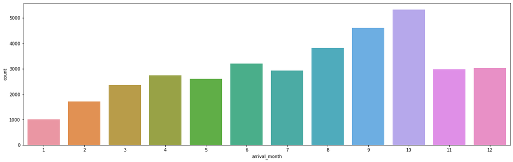

```python
plt.figure(figsize=(20, 6))
sns.countplot(data = hotel_data, x = 'arrival_month')
plt.show()
```

```python
hotel_data['arrival_month'].value_counts()
```

```
10    5317
9     4611
8     3813
6     3203
12    3021
11    2980
7     2920
4     2736
5     2598
3     2358
2     1704
1     1014
Name: arrival_month, dtype: int64
```

**August, September, and October are the busiest months in the hotel. Each of these months have greater than 3500 months.**  
**August has 3,813 bookings. September has 4,611 bookings. October has 5,317 bookings.**  
**March through December all have greater than 2,000 monthly bookings**  
**January and February have the lowest number of bookings.**

**2. Which market segment do most of the guests come from?**

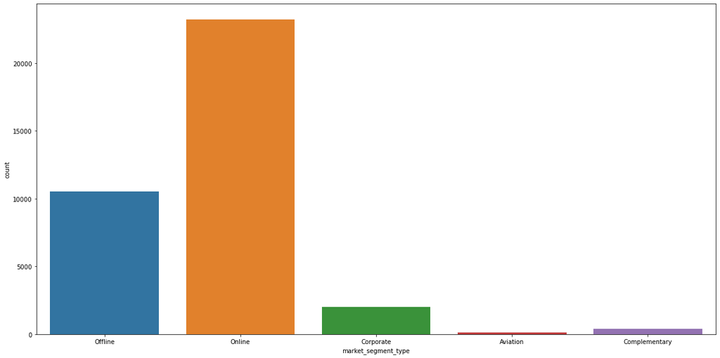

```python
plt.figure(figsize=(20, 10))
sns.countplot(data = hotel_data, x = 'market_segment_type')
plt.show()
```

```python
hotel_data['market_segment_type'].value_counts()
```

```
Online           23214
Offline          10528
Corporate         2017
Complementary      391
Aviation           125
Name: market_segment_type, dtype: int64
```

**Online is by far the most popular market segment with 23,214 total bookings.**  
**Offline is the second most popular market segment with 10,528 bookings.**  
**There are a total of 2,017 total corporate bookings.**  
**There are a low number of complementary and aviation bookings with 391 and 125, respectively.**

**3. Hotel rates are dynamic and change according to demand and customer demographics. What are the differences in room prices in different market segments?**

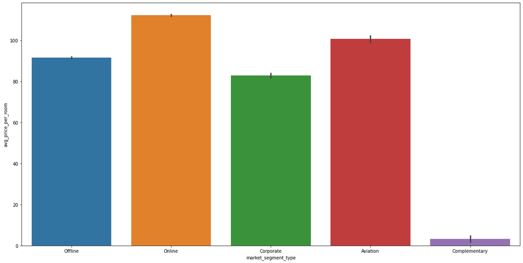

```python
plt.figure(figsize=(20, 10))
sns.barplot(data = hotel_data, x = 'market_segment_type', y = 'avg_price_per_room')
plt.show()
```

```python
hotel_data.groupby('market_segment_type')['avg_price_per_room'].mean()
```

```
market_segment_type
Aviation         100.704000
Complementary      3.141765
Corporate         82.911740
Offline           91.632679
Online           112.256855
Name: avg_price_per_room, dtype: float64
```

**The above graphs takes the average price of the room (over all the days of the booking) and averages that across all bookings within the market segment.**

**Online booking prices tend to cost the most with an average room price per day of \$112.**  
**Aviation bookings are also expensive at \$100 day on average.**  
**Offline bookings tend to be around \$91 per night.**  
**Corporate bookings likely take advantage of en masse pricing and get \$83 per night booking costs.**  
**Complementary bookings are generally free.**

**Analyze complementary booking prices.**

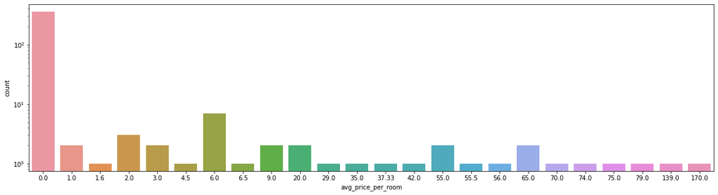

```python
plt.figure(figsize=(20, 5))
ax = sns.countplot(data = hotel_data.where(hotel_data['market_segment_type'] == 'Complementary').dropna(), x = 'avg_price_per_room')
ax.set_yscale('log')
plt.show()
```

**Complementary booking prices are generally 0.0, but in some instances they have a cost.**  
**The chart above is log scaled.**

**4. What percentage of bookings are canceled?**

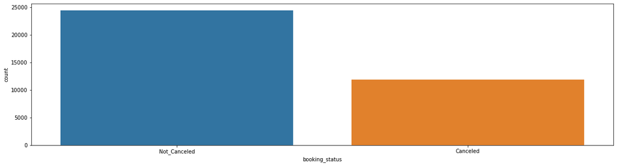

```python
plt.figure(figsize=(20, 5))
ax = sns.countplot(data = hotel_data, x = 'booking_status')
plt.show()
```

```python
not_canceled_count = hotel_data['booking_status'].value_counts()['Not_Canceled']
canceled_count = hotel_data['booking_status'].value_counts()['Canceled']
percentage_canceled = canceled_count / (not_canceled_count + canceled_count) * 100
print(fr'{round(percentage_canceled, 2)}% of bookings have been canceled.')
```

```
32.76% of bookings have been canceled.
```

**32.76% of overall bookings have been canceled.**  
**This percentage is likely different across market segments.**  
**Let's test that hypothesis.**

```python
hotel_segment_status_count = hotel_data.groupby('market_segment_type')['booking_status'].value_counts().to_frame()
hotel_segment_status_count.index = hotel_segment_status_count.index.set_names(['segment', 'status'])
hotel_segment_status_count = hotel_segment_status_count.reset_index(level = [0, 1])
hotel_segment_status_count['percent_canceled'] = 0.0
hotel_segment_status_count.loc[0, 'percent_canceled'] = hotel_segment_status_count.loc[1, 'booking_status'] / \
                                                        (hotel_segment_status_count.loc[0, 'booking_status'] + \
                                                         hotel_segment_status_count.loc[1, 'booking_status'])

hotel_segment_status_count.loc[1, 'percent_canceled'] = hotel_segment_status_count.loc[1, 'booking_status'] / \
                                                        (hotel_segment_status_count.loc[0, 'booking_status'] + \
                                                         hotel_segment_status_count.loc[1, 'booking_status'])

hotel_segment_status_count.loc[2, 'percent_canceled'] = 0.0

hotel_segment_status_count.loc[3, 'percent_canceled'] = hotel_segment_status_count.loc[4, 'booking_status'] / \
                                                        (hotel_segment_status_count.loc[3, 'booking_status'] + \
                                                         hotel_segment_status_count.loc[4, 'booking_status'])

hotel_segment_status_count.loc[4, 'percent_canceled'] = hotel_segment_status_count.loc[4, 'booking_status'] / \
                                                        (hotel_segment_status_count.loc[3, 'booking_status'] + \
                                                         hotel_segment_status_count.loc[4, 'booking_status'])

hotel_segment_status_count.loc[5, 'percent_canceled'] = hotel_segment_status_count.loc[6, 'booking_status'] / \
                                                        (hotel_segment_status_count.loc[5, 'booking_status'] + \
                                                         hotel_segment_status_count.loc[6, 'booking_status'])

hotel_segment_status_count.loc[6, 'percent_canceled'] = hotel_segment_status_count.loc[6, 'booking_status'] / \
                                                        (hotel_segment_status_count.loc[5, 'booking_status'] + \
                                                         hotel_segment_status_count.loc[6, 'booking_status'])

hotel_segment_status_count.loc[7, 'percent_canceled'] = hotel_segment_status_count.loc[8, 'booking_status'] / \
                                                        (hotel_segment_status_count.loc[7, 'booking_status'] + \
                                                         hotel_segment_status_count.loc[8, 'booking_status'])

hotel_segment_status_count.loc[8, 'percent_canceled'] = hotel_segment_status_count.loc[8, 'booking_status'] / \
                                                        (hotel_segment_status_count.loc[7, 'booking_status'] + \
                                                         hotel_segment_status_count.loc[8, 'booking_status'])

canceled_percent_per_segment = hotel_segment_status_count.groupby('segment')['percent_canceled'].mean().to_frame().reset_index(drop = False)
print(canceled_percent_per_segment)
```

```
         segment  percent_canceled
0       Aviation          0.296000
1  Complementary          0.000000
2      Corporate          0.109073
3        Offline          0.299487
4         Online          0.365081
```

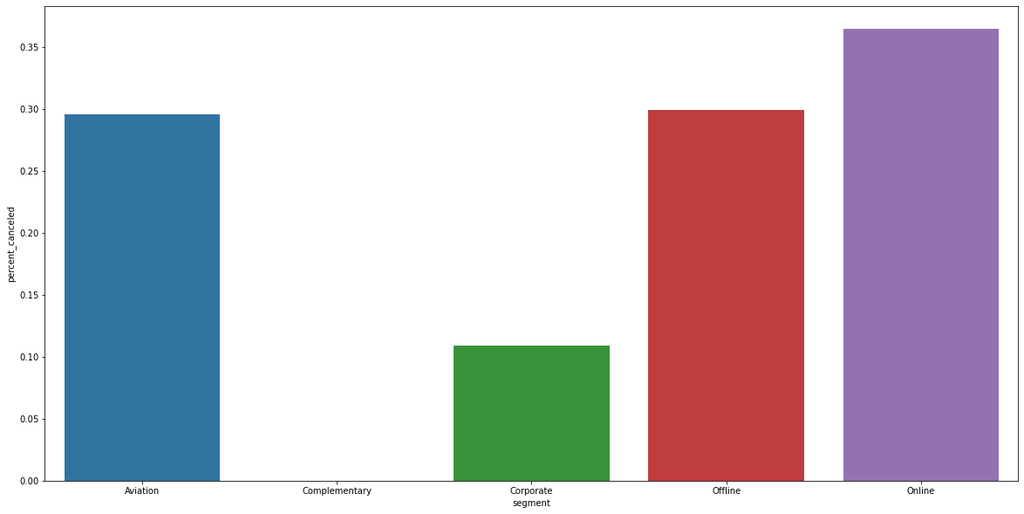

```python
plt.figure(figsize=(20, 10))
sns.barplot(data = canceled_percent_per_segment, x = 'segment', y = 'percent_canceled')
plt.show()
```

**Corporate booking have a relatively low cancelation rate of 10.9%**  
**Aviation and Offline bookings have comparable cancelation rates of around 30%**  
**Complementery bookings have a 0.0% cancelation rate, but cancelation rates do not matter here.**

**5. Repeating guests are the guests who stay in the hotel often and are important to brand equity. What percentage of repeating guests cancel?**

```python
count_repeated_guests = len(hotel_data.loc[hotel_data['repeated_guest'] == 1])
count_repeated_guests_with_cancellations = len(hotel_data.loc[(hotel_data['repeated_guest'] == 1) & (hotel_data['no_of_previous_cancellations'] == 0)])
pct_repeated_guests_who_cancel = count_repeated_guests_with_cancellations / count_repeated_guests * 100
print(fr'{round(pct_repeated_guests_who_cancel, 2)}% of repeated guests have canceled before.')
```

[output not shown]

```python
total_number_of_cancellations_by_repeated_guests = hotel_data.loc[hotel_data['repeated_guest'] == 1, 'no_of_previous_cancellations'].sum()
total_number_of_previous_bookings_not_cancelled_by_repeated_guests =  hotel_data.loc[hotel_data['repeated_guest'] == 1, 'no_of_previous_bookings_not_canceled'].sum()
pct_bookings_cancelled_by_repeated_guests = total_number_of_cancellations_by_repeated_guests /\
                                            (total_number_of_cancellations_by_repeated_guests + total_number_of_previous_bookings_not_cancelled_by_repeated_guests) \
                                            * 100
print(fr'{round(pct_bookings_cancelled_by_repeated_guests, 2)}% of bookings have been cancelled by repeated guests.')
```

```
13.21% of bookings have been cancelled by repeated guests.
```

```python
def gini(x):
    total = 0
    for i, xi in enumerate(x[:-1], 1):
        total += np.sum(np.abs(xi - x[i:]))
    return total / (len(x)**2 * np.mean(x))
```

```python
gini_coefficient = gini(hotel_data.loc[hotel_data['repeated_guest'] == 1, 'no_of_previous_cancellations'].values.flatten())
print(fr'A gini coefficient of {round(gini_coefficient, 4)} represents a relatively high imbalance of cancellations across customers.')
```

```
A gini coefficient of 0.8069 represents a relatively high imbalance of cancellations across customers.
```

**A gini coefficient of 0.8069 represents a relatively high imbalance of cancellations across customers.**

**6. Many guests have special requirements when booking a hotel room. Do these requirements affect booking cancellation?**

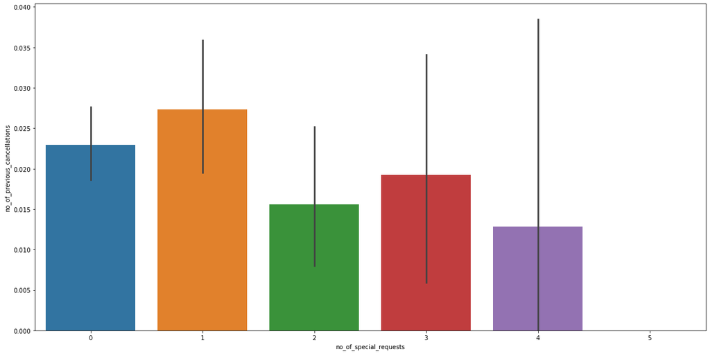

```python
plt.figure(figsize=(20, 10))
sns.barplot(data = hotel_data, x = 'no_of_special_requests', y = 'no_of_previous_cancellations')
plt.show()
```

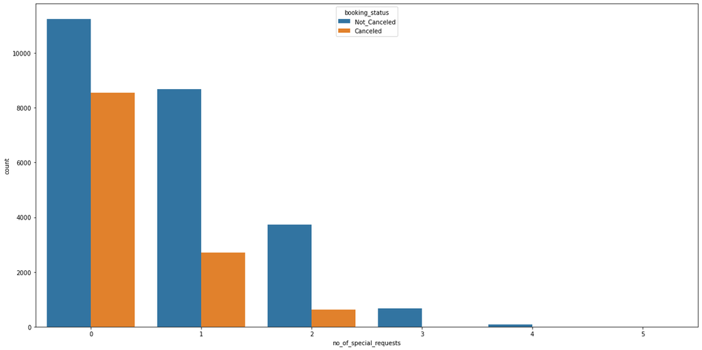

```python
plt.figure(figsize=(20, 10))
sns.countplot(data = hotel_data, x = 'no_of_special_requests', hue = 'booking_status')
plt.show()
```

**Cancellation rate is highly negatively correlated with the number of special requests.**

**Get the correlation across features.**

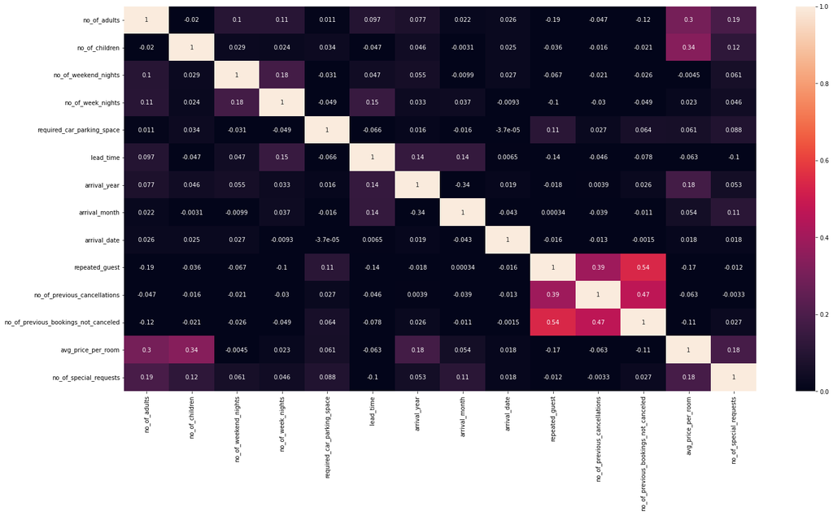

```python
plt.figure(figsize=(24, 12))
ax = sns.heatmap(data = hotel_data.corr(), vmin = 0, vmax = 1, annot = True)
```

## Data Preprocessing

- Missing value treatment (if needed)
- Feature engineering (if needed)
- Outlier detection and treatment (if needed)
- Preparing data for modeling
- Any other preprocessing steps (if needed)

**Missing value treatment**

```python
hotel_data.isna().sum()
```

```
no_of_adults                            0
no_of_children                          0
no_of_weekend_nights                    0
no_of_week_nights                       0
type_of_meal_plan                       0
required_car_parking_space              0
room_type_reserved                      0
lead_time                               0
arrival_year                            0
arrival_month                           0
arrival_date                            0
market_segment_type                     0
repeated_guest                          0
no_of_previous_cancellations            0
no_of_previous_bookings_not_canceled    0
avg_price_per_room                      0
no_of_special_requests                  0
booking_status                          0
dtype: int64
```

**The dataset does not contain missing values.**

**Feature engineering**

```python
hotel_data.dtypes
```

```
no_of_adults                              int64
no_of_children                            int64
no_of_weekend_nights                      int64
no_of_week_nights                         int64
type_of_meal_plan                        object
required_car_parking_space                int64
room_type_reserved                       object
lead_time                                 int64
arrival_year                              int64
arrival_month                             int64
arrival_date                              int64
market_segment_type                      object
repeated_guest                            int64
no_of_previous_cancellations              int64
no_of_previous_bookings_not_canceled      int64
avg_price_per_room                      float64
no_of_special_requests                    int64
booking_status                           object
dtype: object
```

**Perform feature engineering on number of adults.**

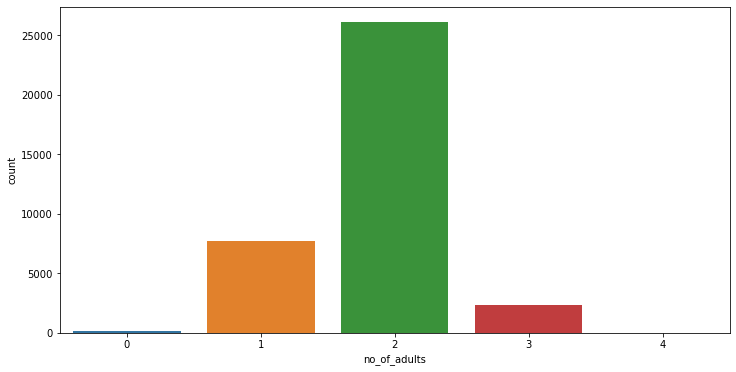

```python
plt.figure(figsize=(12, 6))
sns.countplot(data = hotel_data, x = 'no_of_adults')
plt.show()
```

**Number of adults is ordinal in nature. Reduce the scale of the data from 0 to 1 via a minmax scaler.**

```python
hotel_data['no_of_adults'] = hotel_data['no_of_adults'] / np.max(hotel_data['no_of_adults'])
```

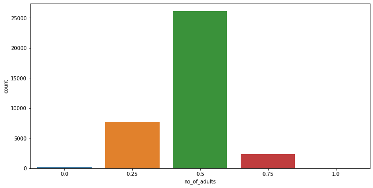

```python
plt.figure(figsize=(12, 6))
sns.countplot(data = hotel_data, x = 'no_of_adults')
plt.show()
```

**Number of adults has been scaled.**

**Perform feature engineering on number of children.**

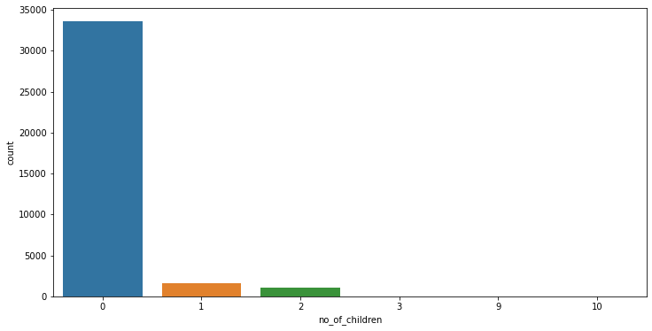

```python
plt.figure(figsize=(12, 6))
sns.countplot(data = hotel_data, x = 'no_of_children')
plt.show()
```

**The data has a heavy right-tail distribution. Perform minmax scaling.**

```python
hotel_data['no_of_children'] = hotel_data['no_of_children'] / np.max(hotel_data['no_of_children'])
```

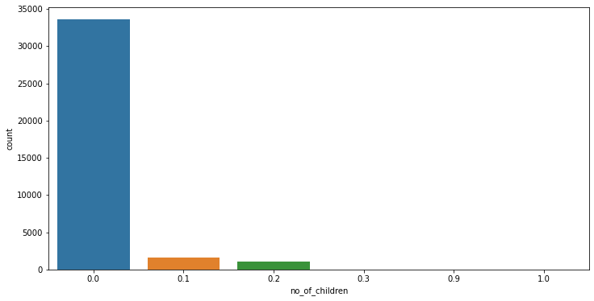

```python
plt.figure(figsize=(12, 6))
sns.countplot(data = hotel_data, x = 'no_of_children')
plt.show()
```

**Data is scaled.**

**Perform feature engineering on number of weekend nights.**

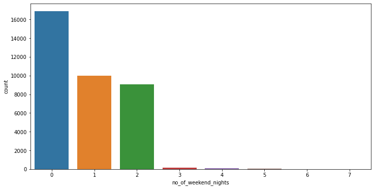

```python
plt.figure(figsize=(12, 6))
sns.countplot(data = hotel_data, x = 'no_of_weekend_nights')
plt.show()
```

**Perform minmax scaling.**

```python
hotel_data['no_of_weekend_nights'] = hotel_data['no_of_weekend_nights'] / np.max(hotel_data['no_of_weekend_nights'])
```

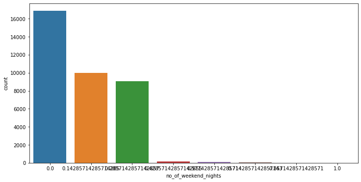

```python
plt.figure(figsize=(12, 6))
sns.countplot(data = hotel_data, x = 'no_of_weekend_nights')
plt.show()
```

**Data is scaled.**

**Perform feature engineering on number of week nights.**

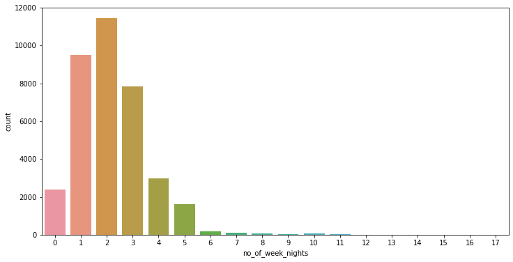

```python
plt.figure(figsize=(12, 6))
sns.countplot(data = hotel_data, x = 'no_of_week_nights')
plt.show()
```

**Data roughly follows a normal distribution. Cap values at greater than 6 to 6. Perform minmax then power scaling afterwards.**

```python
hotel_data.loc[hotel_data['no_of_week_nights'] > 6, 'no_of_week_nights'] = 6
```

```python
hotel_data['no_of_week_nights'] = hotel_data['no_of_week_nights'] / np.max(hotel_data['no_of_week_nights'])
```

```python
hotel_data_week_nights = hotel_data.copy()
```

```python
hotel_data_week_nights['no_of_week_nights'] = hotel_data_week_nights.apply(lambda row: np.power(row['no_of_week_nights'], 0.5), axis = 1)
```

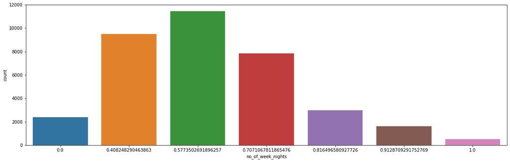

```python
plt.figure(figsize=(20, 6))
sns.countplot(data = hotel_data_week_nights, x = 'no_of_week_nights')
plt.show()
```

**Feature engineering on type of meal plan.**

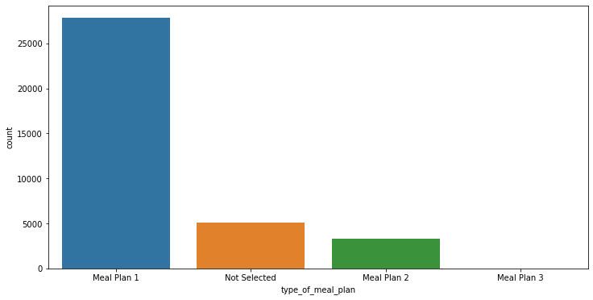

```python
plt.figure(figsize=(12, 6))
sns.countplot(data = hotel_data, x = 'type_of_meal_plan')
plt.show()
```

**One hot encode this feature**

```python
from sklearn.preprocessing import OneHotEncoder
```

```python
encoder = OneHotEncoder()
```

```python
encoded_meal_plan = encoder.fit_transform(hotel_data[['type_of_meal_plan']]).toarray()
```

```python
encoded_df = pd.DataFrame(encoded_meal_plan, columns = ['MP1', 'MP2', 'MP3', 'MP4'])
```

```python
encoded_df
```

|  | MP1 | MP2 | MP3 | MP4 |
| --- | --- | --- | --- | --- |
| 0 | 1.0 | 0.0 | 0.0 | 0.0 |
| 1 | 0.0 | 0.0 | 0.0 | 1.0 |
| 2 | 1.0 | 0.0 | 0.0 | 0.0 |
| 3 | 1.0 | 0.0 | 0.0 | 0.0 |
| 4 | 0.0 | 0.0 | 0.0 | 1.0 |
| ... | ... | ... | ... | ... |
| 36270 | 1.0 | 0.0 | 0.0 | 0.0 |
| 36271 | 1.0 | 0.0 | 0.0 | 0.0 |
| 36272 | 1.0 | 0.0 | 0.0 | 0.0 |
| 36273 | 0.0 | 0.0 | 0.0 | 1.0 |
| 36274 | 1.0 | 0.0 | 0.0 | 0.0 |

36275 rows × 4 columns

```python
hotel_data = hotel_data.join(encoded_df)
```

```python
hotel_data.drop('type_of_meal_plan', axis = 1, inplace = True)
```

**Feature engineering on required car parking space.**

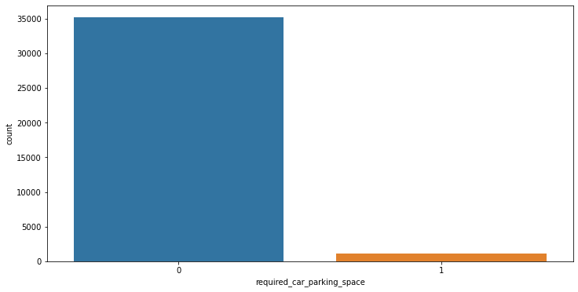

```python
plt.figure(figsize=(12, 6))
sns.countplot(data = hotel_data, x = 'required_car_parking_space')
plt.show()
```

**Nothing needs to be done to this feature.**

**Perform feature engineering on room_type_reserved.**

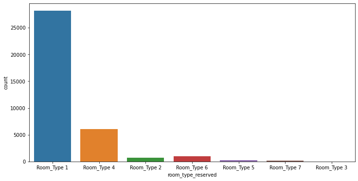

```python
plt.figure(figsize=(12, 6))
sns.countplot(data = hotel_data, x = 'room_type_reserved')
plt.show()
```

**Feature is not ordinal in nature. Therefore, one hot encoding is necessary.**

```python
encoder = OneHotEncoder()
```

```python
encoded_room_type = encoder.fit_transform(hotel_data[['room_type_reserved']]).toarray()
```

```python
encoded_df = pd.DataFrame(encoded_room_type, columns = ['RT1', 'RT2', 'RT3', 'RT4', 'RT5', 'RT6', 'RT7'])
```

```python
encoded_df
```

|  | RT1 | RT2 | RT3 | RT4 | RT5 | RT6 | RT7 |
| --- | --- | --- | --- | --- | --- | --- | --- |
| 0 | 1.0 | 0.0 | 0.0 | 0.0 | 0.0 | 0.0 | 0.0 |
| 1 | 1.0 | 0.0 | 0.0 | 0.0 | 0.0 | 0.0 | 0.0 |
| 2 | 1.0 | 0.0 | 0.0 | 0.0 | 0.0 | 0.0 | 0.0 |
| 3 | 1.0 | 0.0 | 0.0 | 0.0 | 0.0 | 0.0 | 0.0 |
| 4 | 1.0 | 0.0 | 0.0 | 0.0 | 0.0 | 0.0 | 0.0 |
| ... | ... | ... | ... | ... | ... | ... | ... |
| 36270 | 0.0 | 0.0 | 0.0 | 1.0 | 0.0 | 0.0 | 0.0 |
| 36271 | 1.0 | 0.0 | 0.0 | 0.0 | 0.0 | 0.0 | 0.0 |
| 36272 | 1.0 | 0.0 | 0.0 | 0.0 | 0.0 | 0.0 | 0.0 |
| 36273 | 1.0 | 0.0 | 0.0 | 0.0 | 0.0 | 0.0 | 0.0 |
| 36274 | 1.0 | 0.0 | 0.0 | 0.0 | 0.0 | 0.0 | 0.0 |

36275 rows × 7 columns

```python
hotel_data = hotel_data.join(encoded_df)
```

```python
hotel_data.drop('room_type_reserved', axis = 1, inplace = True)
```

**Perform feature engineering on lead time.**

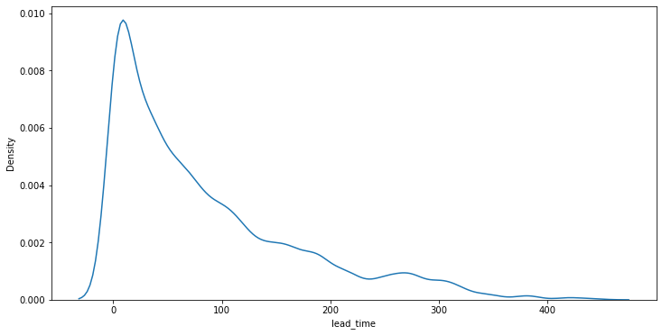

```python
plt.figure(figsize=(12, 6))
sns.kdeplot(data = hotel_data, x = 'lead_time')
plt.show()
```

**Perform minmax scaling then power scaling on lead time.**

```python
hotel_data['lead_time'] -= np.min(hotel_data['lead_time'])
hotel_data['lead_time'] /= np.max(hotel_data['lead_time'])
```

```python
hotel_data['lead_time'].describe()
```

```
count    36275.000000
mean         0.192399
std          0.193975
min          0.000000
25%          0.038375
50%          0.128668
75%          0.284424
max          1.000000
Name: lead_time, dtype: float64
```

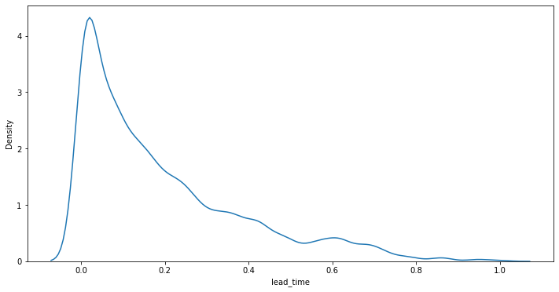

```python
plt.figure(figsize=(12, 6))
sns.kdeplot(data = hotel_data, x = 'lead_time')
plt.show()
```

**Perform the power scaling.**

```python
hotel_data['lead_time'] = np.power(hotel_data['lead_time'], 1/3)
```

```python
hotel_data['lead_time'].describe()
```

```
count    36275.000000
mean         0.495585
std          0.221158
min          0.000000
25%          0.337299
50%          0.504844
75%          0.657641
max          1.000000
Name: lead_time, dtype: float64
```

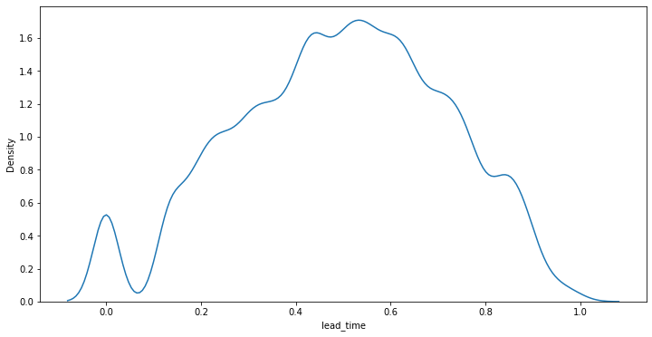

```python
plt.figure(figsize=(12, 6))
sns.kdeplot(data = hotel_data, x = 'lead_time')
plt.show()
```

**Data is now nearly normally distributed and scaled from 0 to 1.**

**Perform feature engineering on arrival year.**

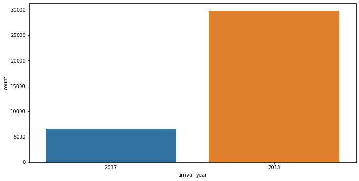

```python
plt.figure(figsize=(12, 6))
sns.countplot(data = hotel_data, x = 'arrival_year')
plt.show()
```

**Convert arrival year into an ordinal field from 0 to 1.**

```python
hotel_data.loc[hotel_data['arrival_year'] == 2017, 'arrival_year'] = 0
hotel_data.loc[hotel_data['arrival_year'] == 2018, 'arrival_year'] = 1
```

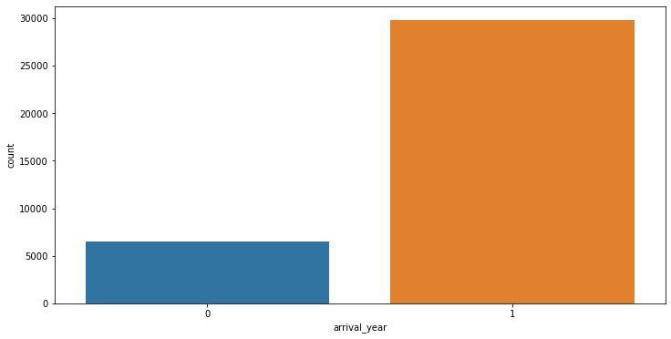

```python
plt.figure(figsize=(12, 6))
sns.countplot(data = hotel_data, x = 'arrival_year')
plt.show()
```

**Arrival year has been converted.**

**Perform feature engineering on arrival month.**

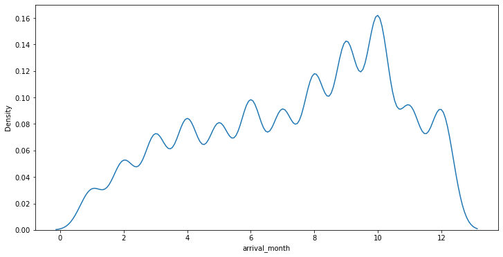

```python
plt.figure(figsize=(12, 6))
sns.kdeplot(data = hotel_data, x = 'arrival_month')
plt.show()
```

**Perform minmax scaling and then power scaling.**

```python
hotel_data['arrival_month'] -= np.min(hotel_data['arrival_month'])
hotel_data['arrival_month'] /= np.max(hotel_data['arrival_month'])
```

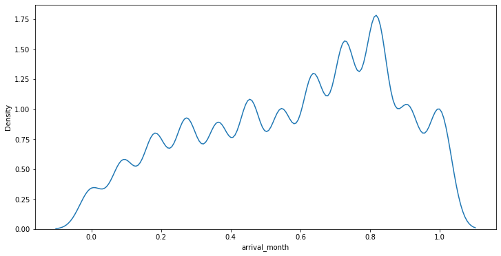

```python
plt.figure(figsize=(12, 6))
sns.kdeplot(data = hotel_data, x = 'arrival_month')
plt.show()
```

**Perform power scaling on the arrival_month**

```python
hotel_data['arrival_month'] = np.power(hotel_data['arrival_month'], 1.5)
```

```python
hotel_data['arrival_month'].describe()
```

```
count    36275.000000
mean         0.487422
std          0.300739
min          0.000000
25%          0.219281
50%          0.507643
75%          0.740073
max          1.000000
Name: arrival_month, dtype: float64
```

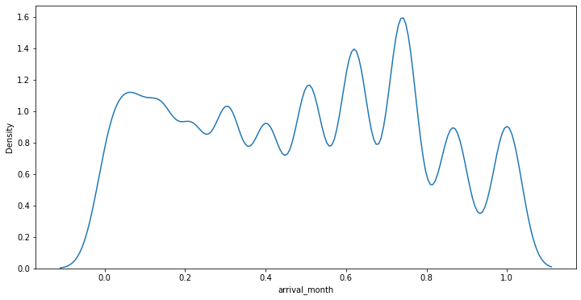

```python
plt.figure(figsize=(12, 6))
sns.kdeplot(data = hotel_data, x = 'arrival_month')
plt.show()
```

**Feature engineering complete for arrival month.**